# P4 Quantitative Signal Detection for Covid Vaccines

## 4.3 Disproportionality Analysis

Using the created contingency tables, we will now apply several well established tests to calculate if there was disproportional reporting. This would give a hint that there might be an association between the administration of a drug and the occurrence of an event. See $^{1}$ for more detailed information.

Some values will be calculated “by hand” and others via available functions.  
We will mark items/values calculated “by hand” with "_c" and items/values obtained via preexisting functions with "_f".

### 4.3.1 $\chi^{2}$ with Yates’ correction

This test is used to identify whether there is a statistically significant association between two independent categorical dichotomous variables.  
“The higher the χ2 value, the more the observed numbers deviate from expected numbers.”$^{2}$

$\chi^{2}$ with Yates correction for 2x2 contingency tables can be calculated as follows:

$$\chi^{2}_{Yates} = \frac{n(|ad − bc|-0.5n)^{2}}{(a + b)(c + d)(a + c)(b + d)}$$
with n (= samplesize) as:
$$n = a + b + c + d$$

calculate $\chi^{2}_{Yates}$:

```r
chi2_yates_c_fun <- function(record){
        a <- record[["a"]]
        b <- record[["b"]]
        c <- record[["c"]]
        d <- record[["d"]]
        n <- a+b+c+d
        chi2 <- (n*(abs(a*d-b*c)-0.5*n )^2)/((a + b)*(c + d)*(a + c)*(b + d))

        return(chi2)
}
chi2 <- cont %>% select(a,b,c,d) %>% apply(., MARGIN = 1, FUN = chi2_yates_c_fun)

chi2 <- cbind(cont[,1:2], chi2_c = chi2)
```

Now we will compare the results, with these of the function chisq.test(correct = TRUE)?  
This function takes data from a contingency table in the following form:

```r
##              D       nD
## ADR          a       b
## nADR         c       d
```

Therefore, we will write a function that does the reformatting before applying chisq.test()

```r
chi2_yates_f_fun <- function(record){
        abcd <- c(as.numeric(record[[3]]), as.numeric(record[[5]]), as.numeric(record[[4]]), as.numeric(record[[6]]))
        cont_table <- matrix(abcd, nrow = 2, ncol = 2)
        result <- chisq.test(cont_table, correct = TRUE)
        return(result)
}

chi2_f_res <- cont %>% apply(., MARGIN = 1, FUN = chi2_yates_f_fun)

#extract chi2 and the p-values
chi2_f <- chi2_f_res %>% lapply(., function(x){
        chi2 <- x[["statistic"]][["X-squared"]]
        return(chi2)
})

pval_f <- chi2_f_res %>% lapply(., function(x){
        pval <- x[["p.value"]]
        return(pval)
})

#bind to chi2 to compare data
chi2 <- chi2_f %>% unlist %>% cbind(chi2, chi2_f = .)
chi2 <- pval_f %>% unlist %>% cbind(chi2, pval_f = .)

#get values that differ significantly
dif <- chi2 %>% cbind(cont[3:6], .) %>% mutate(., dif_c_f = chi2_c - chi2_f) %>% filter(dif_c_f > 0.00001)
kable(dif, format.args = list(scientific = FALSE))
```

| a | b | c | d | Product | Event | chi2_c | chi2_f | pval_f | dif_c_f |
| --- | --- | --- | --- | --- | --- | --- | --- | --- | --- |
| 1 | 266 | 2362 | 1174984 | nos | Anaphylactic shock | 0.0023925 | 0 | 1 | 0.0023925 |
| 1 | 422 | 2362 | 1174828 | nos | Pulmonary arterial hypertension | 0.1436683 | 0 | 1 | 0.1436683 |
| 1 | 809 | 961 | 1153505 | mod | Pancytopenia | 0.0452089 | 0 | 1 | 0.0452089 |
| 1 | 988 | 961 | 1153326 | mod | Angioedema | 0.1273236 | 0 | 1 | 0.1273236 |
| 3 | 1004 | 2999 | 1173603 | pfi | Angioedema | 0.0017587 | 0 | 1 | 0.0017587 |
| 1 | 3286 | 209 | 919347 | jan | Renal failure | 0.0825273 | 0 | 1 | 0.0825273 |

We got some warnings, that the result might not be correct (not included here). This is due to some numbers in the contingency table beeing to small e.g. <5  
The results are mostly the same except for the product event combinations shown above. For these the result from chisq.test() is very small.

I was unable to find the reason for this and proceeded by using the output from the chisq.test().

#### 4.3.1.1 Cut-off

“$\chi^{2}$ values greater than 3.841 indicate statistical significance with p ≤ 0.05, i.e., more than 95% chance that the observed numbers are really different from the expected numbers. Routinely, a $\chi^{2}$ value of 4 (p=0.045) is used as cut-off.”$^{2}$

This statement can be validated by calculating the degrees of freedom of a 2x2 contingency table with r = rows and c = columns, as follows:
$$df = (r-1)(c-1)$$
For a 2x2 contingency table the result therefore is: 1

We can then look up the cut off value for a certain p-value in a chi square table, which gives us 3.841 as stated above.

```r
chi2_sig <- cbind(cont[,1:2], received_cases = cont[,3], chi2_f = chi2$chi2_f) %>% filter(chi2_f >= 3.841) %>% group_by(Product) %>% arrange(desc(chi2_f), .by_group = TRUE)
kable(chi2_sig, digits = 2)
```

| Product | Event | received_cases | chi2_f |
| --- | --- | --- | --- |
| jan | Pulmonary fibrosis | 2 | 28.18 |
| jan | Deafness | 2 | 11.30 |
| jan | Anaphylactic shock | 1 | 4.51 |
| mod | Anaphylactic reaction | 11 | 60.37 |
| mod | Erythema multiforme | 2 | 37.42 |
| mod | Deafness | 6 | 29.43 |
| mod | Anaphylactic shock | 3 | 23.68 |
| mod | Stevens-Johnson syndrome | 2 | 7.20 |
| nos | Erythema multiforme | 2 | 13.42 |
| nos | Deafness | 7 | 11.32 |
| nos | Pulmonary fibrosis | 4 | 9.93 |
| nos | Acute kidney injury | 2 | 7.38 |
| pfi | Anaphylactic reaction | 14 | 19.62 |
| pfi | Deafness | 7 | 7.05 |
| pfi | Pulmonary arterial hypertension | 4 | 5.45 |

#### 4.3.1.2 Interpretation

The $\chi^{2}$ value in the table above provides us with information about how certain we are that the variables (drug / no Drug; ADR / no ADR) are not independent => bigger values means we are more sure that there is an association between administration of the product and occurence of the event.  
We get no information about the strength of the association.

In 2x2 contingency tables where one off the numbers is <5 Fishers’ Exact Test should be preferred to the $\chi^{2}$ statstic. This is the case for many of our product event pairs.

### 4.3.2 Relative Reporting Ratio (RRR)

“Ratio of observed frequency (risk) to expected frequency in the complete population.”$^{2}$

With n = samplesize as:
$$n = a + b + c + d$$
it can be calculated as follows:
$$RRR = \frac{a*n}{(a+c)*(a+b)}$$
Calculate RRR:

```r
rrr_c_fun <- function(record){
        a <- record[["a"]]
        b <- record[["b"]]
        c <- record[["c"]]
        d <- record[["d"]]
        n <- a+b+c+d
        rrr <- (a*n)/((a+c)*(a+b))
        return(rrr)
}

rrr_c <- cont %>% select(a,b,c,d) %>% apply(., MARGIN = 1, FUN = rrr_c_fun)

rrr <- cbind(cont[,1:2], received_cases = cont[,3], rrr_c = rrr_c)
```

#### 4.3.2.1 Cut-off

“A cut-off value of 2 could be used”$^{2}$

I did not find a preexisting function that calculates the RRR, therefore i will just use the calculated results.

```r
rrr_sig <- rrr %>% filter(rrr_c >= 2) %>% group_by(Product) %>% arrange(desc(rrr_c), .by_group = TRUE)
kable(rrr_sig, digits = 2)
```

| Product | Event | received_cases | rrr_c |
| --- | --- | --- | --- |
| jan | Pulmonary fibrosis | 2 | 27.64 |
| jan | Anaphylactic shock | 1 | 21.86 |
| jan | Deafness | 2 | 12.56 |
| jan | Pancreatitis | 1 | 4.73 |
| mod | Erythema multiforme | 2 | 35.85 |
| mod | Anaphylactic shock | 3 | 13.65 |
| mod | Stevens-Johnson syndrome | 2 | 8.86 |
| mod | Anaphylactic reaction | 11 | 7.97 |
| mod | Deafness | 6 | 7.86 |
| mod | Immune thrombocytopenia | 1 | 6.94 |
| mod | Pulmonary fibrosis | 1 | 3.25 |
| nos | Erythema multiforme | 2 | 14.45 |
| nos | Pulmonary fibrosis | 4 | 5.27 |
| nos | Deafness | 7 | 3.71 |
| nos | Pancreatitis acute | 2 | 2.60 |
| pfi | Pulmonary arterial hypertension | 4 | 3.71 |
| pfi | Anaphylactic reaction | 14 | 3.24 |
| pfi | Deafness | 7 | 2.92 |
| pfi | Stevens-Johnson syndrome | 2 | 2.83 |
| pfi | Pulmonary fibrosis | 2 | 2.08 |

#### 4.3.2.2 Confidence Interval

We can also calculate the confidence interval (CI) for the RRR value, via its standard deviation (sd).

The standard deviation is calculated as follows:
$$sd = \sqrt{\frac{c}{a*(a+c)} + \frac{c+d}{n(a+b)}}$$

And the 95% Confidence Interval as:

$$CI = e ^{(ln RRR ± 1.96*sd)}$$
Calculate the standard deviation:

```r
rrr_sd_c_fun <- function(record){
        a <- record[["a"]]
        b <- record[["b"]]
        c <- record[["c"]]
        d <- record[["d"]]
        n <- a + b + c + d
        sd <- sqrt(c/(a*(a+c))+(c+d)/(n*(a+b)))
        return(sd)
}

rrr_sd_c <- cont %>% select(a, b, c, d) %>% apply(., MARGIN = 1, FUN = rrr_sd_c_fun)

rrr_ci <- cbind(rrr, rrr_sd_c = rrr_sd_c)
```

Calculate the confidence interval:

```r
#lower confidence interval
rrr_lci_c_fun <- function(record) {
        rrr <- record[["rrr_c"]]
        sd <- record[["rrr_sd_c"]]
        lci <- exp(log(rrr)-1.96*sd)
        return(lci)
}

rrr_lci_c <- rrr_ci %>% select(rrr_c, rrr_sd_c) %>% apply(., MARGIN = 1, FUN = rrr_lci_c_fun)

#upper confidence interval
rrr_uci_c_fun <- function(record) {
        rrr <- record[["rrr_c"]]
        sd <- record[["rrr_sd_c"]]
        uci <- exp(log(rrr)+1.96*sd)
        return(uci)
}

rrr_uci_c <- rrr_ci %>% select(rrr_c, rrr_sd_c) %>% apply(., MARGIN = 1, FUN = rrr_uci_c_fun)

rrr_ci <- cbind(rrr, rrr_lci_c = rrr_lci_c, rrr_uci_c = rrr_uci_c)
```

Now filter the records for the lower confidence interval being >= 1

```r
rrr_ci_sig <- rrr_ci %>% filter(rrr_lci_c >= 1) %>% group_by(Product) %>% arrange(desc(rrr_lci_c), .by_group = TRUE)
kable(rrr_ci_sig, digits = 2)
```

| Product | Event | received_cases | rrr_c | rrr_lci_c | rrr_uci_c |
| --- | --- | --- | --- | --- | --- |
| jan | Pulmonary fibrosis | 2 | 27.64 | 6.93 | 110.26 |
| jan | Deafness | 2 | 12.56 | 3.15 | 49.97 |
| jan | Anaphylactic shock | 1 | 21.86 | 3.08 | 155.25 |
| mod | Erythema multiforme | 2 | 35.85 | 8.80 | 146.11 |
| mod | Anaphylactic reaction | 11 | 7.97 | 4.42 | 14.37 |
| mod | Anaphylactic shock | 3 | 13.65 | 4.38 | 42.51 |
| mod | Deafness | 6 | 7.86 | 3.53 | 17.49 |
| mod | Stevens-Johnson syndrome | 2 | 8.86 | 2.21 | 35.57 |
| nos | Erythema multiforme | 2 | 14.45 | 3.54 | 58.89 |
| nos | Pulmonary fibrosis | 4 | 5.27 | 1.97 | 14.11 |
| nos | Deafness | 7 | 3.71 | 1.77 | 7.80 |
| pfi | Anaphylactic reaction | 14 | 3.24 | 1.92 | 5.48 |
| pfi | Deafness | 7 | 2.92 | 1.39 | 6.14 |
| pfi | Pulmonary arterial hypertension | 4 | 3.71 | 1.39 | 9.92 |

Plot:

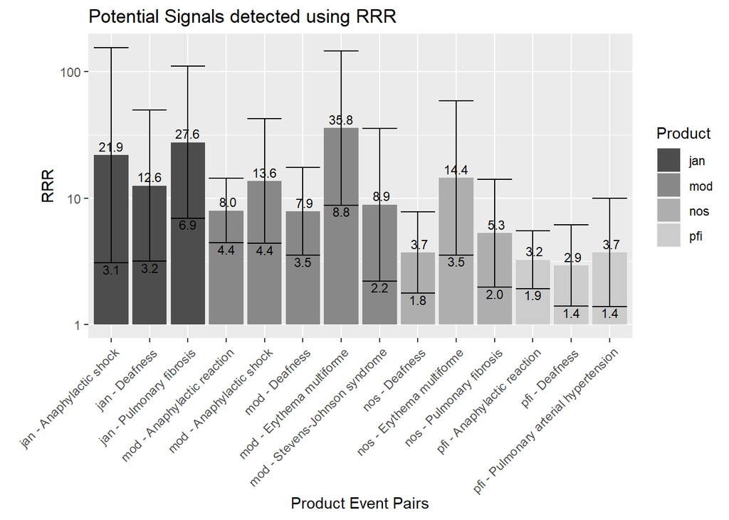

```r
rrr_ci_sig %>% ggplot(., aes(x = paste(Product, Event, sep = " - "), y = rrr_c, fill = Product)) +
        geom_bar(stat = "identity") +
        geom_errorbar(aes(x = paste(Product, Event, sep = " - "), ymin = rrr_lci_c, ymax = rrr_uci_c)) +
        scale_y_log10() +
        theme(axis.text.x = element_text(angle = 45, hjust = 0.99, vjust = 0.99)) +
        labs(title = "Potential Signals detected using RRR") +
        xlab(label = "Product Event Pairs") +
        ylab(label = "RRR") +
        geom_text(aes(y = rrr_c, x = paste(Product, Event, sep = " - "), label = format(rrr_c, digits = 2)), size = 3, nudge_y = 0.07) +
        geom_text(aes(y = rrr_lci_c, x = paste(Product, Event, sep = " - "), label = format(rrr_lci_c, digits = 2)), size = 3, nudge_y = -0.05) +
        theme(plot.margin = margin(0.2, 0.2, 0.2, 1, "cm")) +
        scale_fill_grey(start = 0.3)
```

Compared to using rrr > 2 as cut-off, here we get only 14 potential signals instead of the 20 above.

#### 4.3.2.3 Interpretation

For the product event pairs above we are at least 95 % sure that there is an association between application of the product and the event. The best guess of the strength of the association (with this method) is the rrr_c value.

### 4.3.3 Proportional Reporting Ratio (PRR)

“This is analogous to a relative risk, but applied to spontaneous report data, and therefore with associated weaker inferential capability […]”$^{1}$

The formula for the PRR value is as follows:
$$PRR = \frac{a/(a + b)}{c/(c + d)}$$
Calculate PRR value:

```r
PRR <- cont %>% transmute(., PRR = (a/(a+b))/(c/(c+d))) %>% cbind(cont[,c("Product", "Event", "a")], .)
```

#### 4.3.3.1 Cut-off

“Routinely, a cut off value of 2 is used to identify signals.”$^{2}$

Filter for records with PRR >= 2 and display them:

```r
colnames(PRR) <- c("Product", "Event", "Received Cases", "PRR")
PRR_sig <- PRR %>% filter(PRR >= 2) %>% group_by(Product) %>% arrange(desc(PRR), .by_group = TRUE)
kable(PRR_sig, digits = 2)
```

| Product | Event | Received Cases | PRR |
| --- | --- | --- | --- |
| jan | Pulmonary fibrosis | 2 | 27.89 |
| jan | Anaphylactic shock | 1 | 21.96 |
| jan | Deafness | 2 | 12.67 |
| jan | Pancreatitis | 1 | 4.74 |
| mod | Erythema multiforme | 2 | 35.92 |
| mod | Anaphylactic shock | 3 | 13.69 |
| mod | Stevens-Johnson syndrome | 2 | 8.88 |
| mod | Anaphylactic reaction | 11 | 8.05 |
| mod | Deafness | 6 | 7.90 |
| mod | Immune thrombocytopenia | 1 | 6.95 |
| mod | Pulmonary fibrosis | 1 | 3.25 |
| nos | Erythema multiforme | 2 | 14.46 |
| nos | Pulmonary fibrosis | 4 | 5.28 |
| nos | Deafness | 7 | 3.72 |
| nos | Pancreatitis acute | 2 | 2.60 |
| pfi | Pulmonary arterial hypertension | 4 | 3.71 |
| pfi | Anaphylactic reaction | 14 | 3.25 |
| pfi | Deafness | 7 | 2.93 |
| pfi | Stevens-Johnson syndrome | 2 | 2.83 |
| pfi | Pulmonary fibrosis | 2 | 2.08 |

There are some product event pairs, that are included where there was only one received case.

#### 4.3.3.2 Confidence Interval

We can also calculate the confidence interval (CI) for the PRR value, via its standard deviation (sd).

The standard deviation is calculated as follows:
$$sd = \sqrt{\frac{c}{a*(a+c)} + \frac{d}{b*(b+d)}}$$

And the 95% confidence interval as:

$$CI = e ^{(ln PRR ± 1.96*sd)}$$
Calculate the standard deviation:

```r
prr_sd_c_fun <- function(record){
        a <- record[["a"]] %>% as.numeric
        b <- record[["b"]] %>% as.numeric
        c <- record[["c"]] %>% as.numeric
        d <- record[["d"]] %>% as.numeric
        sd <- sqrt(c/(a*(a+c))+d/(b*(b+d)))
        return(sd)
}

prr_sd_c <- cont %>% apply(., MARGIN = 1, FUN = prr_sd_c_fun)

PRR_CI <- cbind(PRR, prr_sd_c = prr_sd_c)
```

And the confidence interval:

```r
#lower confidence interval
prr_lci_c_fun <- function(record) {
        PRR <- record[["PRR"]]
        sd <- record[["prr_sd_c"]]
        lci <- exp(log(PRR)-1.96*sd)
        return(lci)
}

prr_lci_c <- PRR_CI %>% select(PRR, prr_sd_c) %>% apply(., MARGIN = 1, FUN = prr_lci_c_fun)

#upper confidence interval
prr_uci_c_fun <- function(record) {
        PRR <- record[["PRR"]]
        sd <- record[["prr_sd_c"]]
        uci <- exp(log(PRR)+1.96*sd)
        return(uci)
}

prr_uci_c <- PRR_CI %>% select(PRR, prr_sd_c) %>% apply(., MARGIN = 1, FUN = prr_uci_c_fun)

PRR_CI <- cbind(PRR_CI, prr_lci_c = prr_lci_c, prr_uci_c = prr_uci_c)
```

Now filter for the records with lci >= 1 and plot the results:

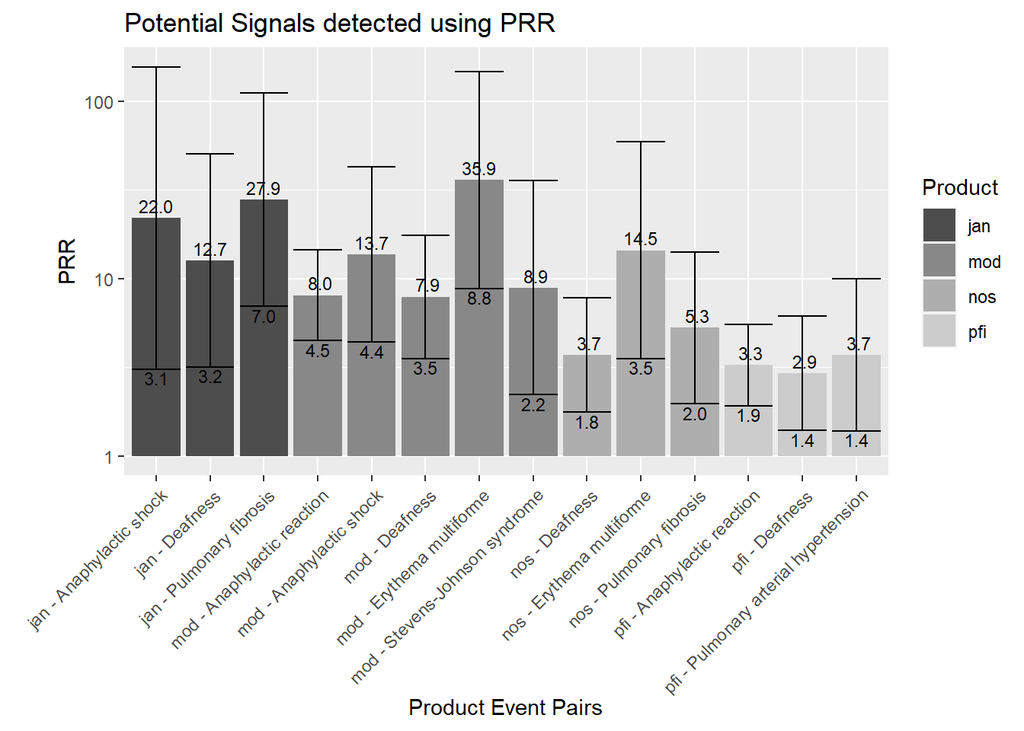

```r
PRR_CI_sig <- PRR_CI %>% filter(prr_lci_c >= 1) %>% group_by(Product) %>% arrange(desc(prr_lci_c), .by_group = TRUE)

PRR_CI_sig %>% ggplot(., aes(x = paste(Product, Event, sep = " - "), y = PRR, fill = Product)) +
        geom_bar(stat = "identity") +
        geom_errorbar(aes(x = paste(Product, Event, sep = " - "), ymin = prr_lci_c, ymax = prr_uci_c)) +
        scale_y_log10() +
        theme(axis.text.x = element_text(angle = 45, hjust = 0.99, vjust = 0.99)) +
        labs(title = "Potential Signals detected using PRR") +
        xlab(label = "Product Event Pairs") +
        ylab(label = "PRR") +
        geom_text(aes(y = PRR, x = paste(Product, Event, sep = " - "), label = format(PRR, digits = 2)), size = 3, nudge_y = 0.07) +
        geom_text(aes(y = prr_lci_c, x = paste(Product, Event, sep = " - "), label = format(prr_lci_c, digits = 2)), size = 3, nudge_y = -0.05) +
        theme(plot.margin = margin(0.2, 0.2, 0.2, 1, "cm")) +
        scale_fill_grey(start = 0.3)
```

#### 4.3.3.3 Interpretation

The probability, that the confidence interval contains the true value of PRR and that therefore there is an association between the administration of the product and the event is >= 95% for all the product event pairs with a lower confidence interval (lci) over 1.  
The PRR value gives the best estimate with this method about how strong the association might be.

Taking the lower confidence interval as a cut-off allowed to eliminate 6 product event pairs compared to taking the cut-off for PRR >= 2 as done above.

The results using RRR and PRR are very similar.

### 4.3.4 ROR

“An obvious alternative [to PRR] is to use an odds ratio (ad/bc), sometimes referred to as a “reporting odds ratio,” or ROR. This has slightly more desirable statistical properties than a PRR […] but will be very similar in magnitude since in most circumstances b >> a and d >> c, and it is questionable whether this has any practical impact on routine pharmacovigilance" $^{1}$

The ROR can be calculated as follows:
$$ROR = \frac{ad}{bc}$$
Calculate ROR value:

```r
ROR <- cont %>% transmute(., ROR = (a*d)/(b*c)) %>% cbind(cont[,c("Product", "Event", "a")], .)
colnames(ROR) <- c("Product", "Event", "Received Cases", "ROR")
```

Create Table with results for PRR and ROR and display it:

```r
meas_disp <- cbind(PRR, ROR = ROR$ROR)
kable(head(meas_disp), digits = 2)
```

|  | Product | Event | Received Cases | PRR | ROR |
| --- | --- | --- | --- | --- | --- |
| 1 | nos | Acute kidney injury | 2 | 0.17 | 0.17 |
| 2 | nos | Deafness | 7 | 3.72 | 3.74 |
| 3 | nos | Anaphylactic reaction | 6 | 1.77 | 1.77 |
| 6 | nos | Anaphylactic shock | 1 | 1.87 | 1.87 |
| 7 | nos | Pulmonary fibrosis | 4 | 5.28 | 5.33 |
| 13 | nos | Renal failure | 5 | 0.60 | 0.60 |

The results for PRR and ROR are indeed very similar.

### 4.3.5 Fishers exact Test

To calculate the p-value and the confidence interval of the ROR we will use Fishers exact test. It can be seen as alternative to the $\chi^{2}$ test we had used above. Fishers exact test is to be used, whenever there is one value <5 in the contingency table. In our case, this is the case for some product event pairs, where a < 5.

We will use the function stats::fisher.test, which takes a contingency table in the following form:

```r
##              D       nD
## ADR          a       b
## nADR         c       d
```

Therefore, we have to create this table before applying the function on it. Try this for one record:

```r
cont_fish <- data.frame(t(cont[1,c(3, 5)]), t(cont[1,c(4, 6)]))
colnames(cont_fish) <- c("D", "nD")
```

Apply the function and display the results:

```r
result_fish <- fisher.test(cont_fish)
result_fish
```

```
##
##  Fisher's Exact Test for Count Data
##
## data:  cont_fish
## p-value = 0.001117
## alternative hypothesis: true odds ratio is not equal to 1
## 95 percent confidence interval:
##  0.02039176 0.60959896
## sample estimates:
## odds ratio
##  0.1684944
```

Extract values from the result:

```r
a <- c(result_fish[["p.value"]])
print(a)
```

```
## [1] 0.001117029
```

```r
result_fish[["conf.int"]][1:2]
```

```
## [1] 0.02039176 0.60959896
```

```r
result_fish[["estimate"]][["odds ratio"]]
```

```
## [1] 0.1684944
```

Write a for loop to run over all of the data:

```r
#set up dataframe to store results
fish_f <- data.frame(matrix(ncol = 4,nrow = 0))

for (i in 1:37) {
        cont_fish <- data.frame(t(cont[i,c(3, 5)]), t(cont[i,c(4, 6)]))
        colnames(cont_fish) <- c("D", "nD")
        result <- fisher.test(cont_fish)
        result_val <- c(result[["p.value"]], result[["conf.int"]][1],
                        result[["conf.int"]][2], result[["estimate"]][["odds ratio"]])
        fish_f <- rbind(fish_f, result_val)
}

fish_f <- cbind(cont[,1:3], fish_f)
colnames(fish_f) <- c("Product", "Event", "Received Cases", "p.val_fish", "lci_fish", "uci_fish", "ROR_fish")
```

Compare the calculated ROR to the value calculated above “by hand”:

```r
cbind(ROR[,1:3], ROR_c = ROR[,4], ROR_fish = fish_f[,"ROR_fish"]) %>% head() %>% kable(., digits = 2)
```

|  | Product | Event | Received Cases | ROR_c | ROR_fish |
| --- | --- | --- | --- | --- | --- |
| 1 | nos | Acute kidney injury | 2 | 0.17 | 0.17 |
| 2 | nos | Deafness | 7 | 3.74 | 3.74 |
| 3 | nos | Anaphylactic reaction | 6 | 1.77 | 1.77 |
| 6 | nos | Anaphylactic shock | 1 | 1.87 | 1.87 |
| 7 | nos | Pulmonary fibrosis | 4 | 5.33 | 5.33 |
| 13 | nos | Renal failure | 5 | 0.60 | 0.60 |

The values are the same.

#### 4.3.5.1 Cut-off

“As with the PRR […], a ROR value of 2 can be used as threshold. However, usually the lower and upper bounds of the confidence interval of ROR are instead used […]. The confidence interval must not cross the value 1 for statistical significance.”$^{2}$

Show these product event pairs.

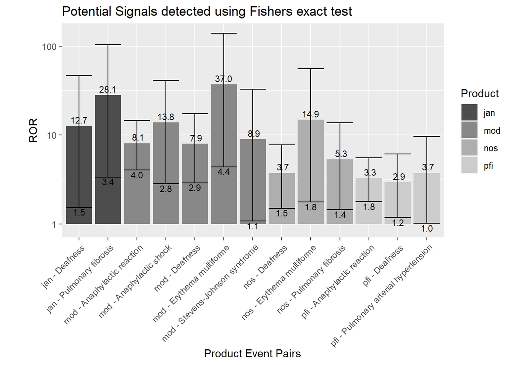

```r
fish_f_sig <-  fish_f %>% group_by(Product) %>% arrange(desc(lci_fish), .by_group = TRUE) %>% filter(lci_fish >= 1)
#kable(fish_f_sig, digits = c(1,1,1,4,2,2,2))

fish_f_sig %>% ggplot(., aes(x = paste(Product, Event, sep = " - "), y = ROR_fish, fill = Product)) +
        geom_bar(stat = "identity") +
        geom_errorbar(aes(x = paste(Product, Event, sep = " - "), ymin = lci_fish, ymax = uci_fish)) +
        scale_y_log10() +
        theme(axis.text.x = element_text(angle = 45, hjust = 0.99, vjust = 0.99)) +
        labs(title = "Potential Signals detected using Fishers exact test") +
        xlab(label = "Product Event Pairs") +
        ylab(label = "ROR") +
        geom_text(aes(y = ROR_fish, x = paste(Product, Event, sep = " - "), label = format(ROR_fish, digits = 2)), size = 3, nudge_y = 0.07) +
        geom_text(aes(y = lci_fish, x = paste(Product, Event, sep = " - "), label = format(lci_fish, digits = 2)), size = 3, nudge_y = -0.05) +
        theme(plot.margin = margin(0.2, 0.2, 0.2, 1, "cm")) +
        scale_fill_grey(start = 0.3)
```

#### 4.3.5.2 Interpretation

The probability, that the confidence interval contains the true value of ROR and that therefore there is an association between the administration of the product and the event is >= 95% for all the product event pairs with a lower confidence interval (lci) over 1.  
The ROR value gives the best estimate from the data about how strong the association might be.

### 4.3.6 Bayesian Confidence Propagation Neural Network (BCPNN)

This method is based on the Information Component. The confidence Interval of the Information Component shrinks over time with increasing amount of data.$^{2}$

The mdsstat package contains a function that calculates the Information component via a Bayesian Confidence Propagation Neural Network: bcpnn()

“Test on device-events using a one-layer BCPNN as proposed by Bate et al (1998), which assumes beta-distributed probabilities and a normal approximation of the variance of the information component (IC).”$^{3}$

This function takes a dataframe containing the values of the contingency tables and a column called “times” (= “Unique times of class Date”). As I understand this for the case that one has a contingency table for more then one point in time. In the default it is not necessary to have values for several times, therefore the dataframe only needs one record and time can be set to 1.

Load the mdsstat library and its dependencies:

```r
library(mds)
library(mdsstat)
```

Create dataframe for Input:

```r
cont_mdsstat <- cont[,1:2]
cont_mdsstat$time <- 1
cont_mdsstat <- cbind(cont_mdsstat, cont[,3:6])
colnames(cont_mdsstat) <- c("Product", "Event", "time", "nA", "nB", "nC", "nD")
```

```r
ror_test <- cont_mdsstat[cont_mdsstat$Product == "jan" & cont_mdsstat$Event == "Pulmonary fibrosis",3:7] %>% bcpnn()
ror_test[["result"]][["statistic"]][[1]]
```

```
## [1] 3.439803
```

Now try running it over the whole dataframe:

```r
ror_mdsstat <- data.frame(matrix(ncol = 1, nrow = 0))
colnames(ror_mdsstat) <- c("ROR")

for (i in 1:37) {
        result <- cont_mdsstat[i,3:7] %>% ror()
        result_stat <- result["result"] %>% unlist %>% .[[1]] #unwrap the result
        ror_mdsstat <- rbind(ror_mdsstat, result_stat)
}
```

This works.

Calculate the Information Component for all product-event pairs:

```r
ic_mdsstat <- data.frame(matrix(ncol = 4, nrow = 0))
colnames(ic_mdsstat) <- c("IC", "p-val", "lcl", "ucl")

for (i in 1:37) {
        result <- cont_mdsstat[i,3:7] %>% bcpnn()
        ic_mdsstat[i,"IC"] <- result[["result"]][["statistic"]][[1]]
        ic_mdsstat[i,"p-val"] <- result[["result"]][["p"]][[1]]
        ic_mdsstat[i,"lcl"] <- result[["result"]][["lcl"]]
        ic_mdsstat[i,"ucl"] <- result[["result"]][["ucl"]]
}

ic_mdsstat <- cbind(cont_mdsstat[,1:2], ic_mdsstat)
```

#### 4.3.6.1 Cut-off

Display these results:

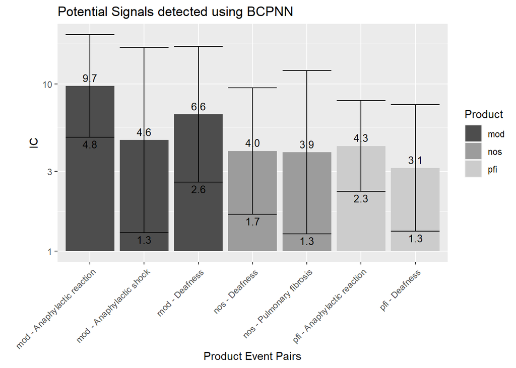

```r
ic_mdsstat_sig <- ic_mdsstat %>% filter(`p-val` < 0.05) %>% group_by(Product) %>%
        arrange(desc(IC), .by_group = TRUE)

ic_mdsstat_sig %>% ggplot(., aes(x = paste(Product, Event, sep = " - "), y = IC, fill = Product)) +
        geom_bar(stat = "identity") +
        geom_errorbar(aes(x = paste(Product, Event, sep = " - "), ymin = lcl, ymax = ucl)) +
        scale_y_log10() +
        theme(axis.text.x = element_text(angle = 45, hjust = 0.99, vjust = 0.99)) +
        labs(title = "Potential Signals detected using BCPNN") +
        xlab(label = "Product Event Pairs") +
        ylab(label = "IC") +
        geom_text(aes(y = IC, x = paste(Product, Event, sep = " - "), label = format(IC, digits = 2)), size = 3.5, nudge_y = 0.05) +
        geom_text(aes(y = lcl, x = paste(Product, Event, sep = " - "), label = format(lcl, digits = 2)), size = 3.5, nudge_y = -0.04) +
        theme(plot.margin = margin(0.2, 0.2, 0.2, 1, "cm")) +
        scale_fill_grey(start = 0.3)
```

This method results in less potential signals, then the methods used so far.

### 4.3.7 Overview

We will now create an overview over the findings from the different methods. In order to compare the significance levels of the results between the test we will use the p-value. In some cases we have to calculate it from the confidence interval, namely for the RRR and PRR.

Write function to calculate the p-value:

```r
pval <- function(est_lcl_ucl){
        est <- est_lcl_ucl[[1]]
        lcl <- est_lcl_ucl[[2]]
        ucl <- est_lcl_ucl[[3]]

        SE <- (log(ucl) - log(lcl))/(2*1.96)
        z <- log(est)/SE
        p <- exp(-0.717*abs(z) - 0.416*(abs(z)^2))
        return(p)
}
```

Calculate the p-value for RRR:

```r
rrr_ci_p <- rrr_ci %>% select(rrr_c, rrr_lci_c, rrr_uci_c) %>% apply(., 1, pval) %>% cbind(rrr_ci, pval = .)

#control if the result is correct
rrr_ci_p %>% filter(pval <= 0.05) %>% kable()
```

| Product | Event | received_cases | rrr_c | rrr_lci_c | rrr_uci_c | pval |
| --- | --- | --- | --- | --- | --- | --- |
| nos | Acute kidney injury | 2 | 0.1694794 | 0.0424002 | 0.6774317 | 0.0119977 |
| nos | Deafness | 7 | 3.7111169 | 1.7662621 | 7.7974773 | 0.0005715 |
| nos | Pulmonary fibrosis | 4 | 5.2735716 | 1.9706500 | 14.1123782 | 0.0009745 |
| nos | Erythema multiforme | 2 | 14.4450496 | 3.5433035 | 58.8883948 | 0.0002159 |
| mod | Deafness | 6 | 7.8575804 | 3.5296253 | 17.4923867 | 0.0000007 |
| mod | Anaphylactic reaction | 11 | 7.9673027 | 4.4185280 | 14.3663031 | 0.0000000 |
| mod | Anaphylactic shock | 3 | 13.6466641 | 4.3808138 | 42.5106961 | 0.0000084 |
| mod | Stevens-Johnson syndrome | 2 | 8.8627935 | 2.2083935 | 35.5684392 | 0.0021411 |
| mod | Erythema multiforme | 2 | 35.8480156 | 8.7955601 | 146.1055589 | 0.0000009 |
| pfi | Deafness | 7 | 2.9211756 | 1.3899750 | 6.1391514 | 0.0047117 |
| pfi | Anaphylactic reaction | 14 | 3.2437949 | 1.9193209 | 5.4822544 | 0.0000139 |
| pfi | Pulmonary arterial hypertension | 4 | 3.7094482 | 1.3866797 | 9.9229882 | 0.0090171 |
| jan | Deafness | 2 | 12.5556599 | 3.1546301 | 49.9724495 | 0.0003576 |
| jan | Anaphylactic shock | 1 | 21.8631367 | 3.0789668 | 155.2458276 | 0.0020925 |
| jan | Pulmonary fibrosis | 2 | 27.6382450 | 6.9276173 | 110.2648366 | 0.0000035 |

```r
rrr_ci_p %>% filter(pval >= 0.05) %>% kable()
```

| Product | Event | received_cases | rrr_c | rrr_lci_c | rrr_uci_c | pval |
| --- | --- | --- | --- | --- | --- | --- |
| nos | Anaphylactic reaction | 6 | 1.7661577 | 0.7931363 | 3.932884 | 0.1644354 |
| nos | Anaphylactic shock | 1 | 1.8664983 | 0.2620584 | 13.294046 | 0.5443351 |
| nos | Renal failure | 5 | 0.6007132 | 0.2501298 | 1.442676 | 0.2571257 |
| nos | Angioedema | 1 | 0.4948908 | 0.0696707 | 3.515351 | 0.4916806 |
| nos | Pancreatitis acute | 2 | 2.5955948 | 0.6471794 | 10.409962 | 0.1792996 |
| nos | Drug-induced liver injury | 2 | 1.6584167 | 0.4140439 | 6.642643 | 0.4844765 |
| nos | Pulmonary arterial hypertension | 1 | 1.1781443 | 0.1656365 | 8.379941 | 0.8793339 |
| nos | Pancreatitis | 2 | 0.7973667 | 0.1993106 | 3.189964 | 0.7617389 |
| mod | Acute kidney injury | 3 | 0.6242799 | 0.2016362 | 1.932815 | 0.4216218 |
| mod | Pancytopenia | 1 | 1.4826057 | 0.2087978 | 10.527506 | 0.7069266 |
| mod | Pulmonary fibrosis | 1 | 3.2457043 | 0.4564409 | 23.079870 | 0.2419288 |
| mod | Immune thrombocytopenia | 1 | 6.9416798 | 0.9732679 | 49.510436 | 0.0528517 |
| mod | Renal failure | 1 | 0.2938367 | 0.0414217 | 2.084417 | 0.2224696 |
| mod | Angioedema | 1 | 1.2142675 | 0.1710447 | 8.620235 | 0.8565171 |
| mod | Pancreatitis | 2 | 1.9590677 | 0.4900984 | 7.830971 | 0.3469960 |
| pfi | Pulmonary fibrosis | 2 | 2.0755317 | 0.5174140 | 8.325696 | 0.3071793 |
| pfi | Stevens-Johnson syndrome | 2 | 2.8323140 | 0.7051333 | 11.376575 | 0.1425398 |
| pfi | Renal failure | 4 | 0.3782779 | 0.1419977 | 1.007721 | 0.0514368 |
| pfi | Angioedema | 3 | 1.1686439 | 0.3764836 | 3.627591 | 0.7996354 |
| pfi | Rhabdomyolysis | 2 | 1.4187178 | 0.3540852 | 5.684395 | 0.6340658 |
| jan | Renal failure | 1 | 1.3369305 | 0.1891435 | 9.449878 | 0.7835667 |
| jan | Pancreatitis | 1 | 4.7252586 | 0.6680045 | 33.425029 | 0.1197404 |

Filtering for pval <= 0.05 gave us all the values, where the 95 % confidence interval excludes 1. => it seems to work correctly.

Calculate the p-values for PRR:

```r
#calculate the p value for RRR
PRR_CI_p <- PRR_CI %>% select(PRR, prr_lci_c, prr_uci_c) %>% apply(., 1, pval) %>% cbind(PRR_CI, pval = .)

#control if the result is correct
PRR_CI_p %>% filter(pval <= 0.05) %>% kable()
```

| Product | Event | Received Cases | PRR | prr_sd_c | prr_lci_c | prr_uci_c | pval |
| --- | --- | --- | --- | --- | --- | --- | --- |
| nos | Acute kidney injury | 2 | 0.1687759 | 0.7069272 | 0.0422242 | 0.6746196 | 0.0118011 |
| nos | Deafness | 7 | 3.7191720 | 0.3788204 | 1.7700593 | 7.8145633 | 0.0005601 |
| nos | Pulmonary fibrosis | 4 | 5.2808180 | 0.5022447 | 1.9732489 | 14.1325502 | 0.0009659 |
| nos | Erythema multiforme | 2 | 14.4564389 | 0.7172875 | 3.5440015 | 58.9696778 | 0.0002163 |
| mod | Deafness | 6 | 7.9006196 | 0.4083185 | 3.5488973 | 17.5885029 | 0.0000006 |
| mod | Anaphylactic reaction | 11 | 8.0478919 | 0.3007921 | 4.4631628 | 14.5118086 | 0.0000000 |
| mod | Anaphylactic shock | 3 | 13.6862262 | 0.5797624 | 4.3931905 | 42.6370736 | 0.0000082 |
| mod | Stevens-Johnson syndrome | 2 | 8.8791744 | 0.7089973 | 2.2123913 | 35.6355306 | 0.0021235 |
| mod | Erythema multiforme | 2 | 35.9206157 | 0.7171780 | 8.8078428 | 146.4933763 | 0.0000009 |
| pfi | Deafness | 7 | 2.9256658 | 0.3789393 | 1.3920828 | 6.1487150 | 0.0046545 |
| pfi | Anaphylactic reaction | 14 | 3.2543080 | 0.2677503 | 1.9255067 | 5.5001215 | 0.0000131 |
| pfi | Pulmonary arterial hypertension | 4 | 3.7130632 | 0.5020485 | 1.3879699 | 9.9330961 | 0.0089697 |
| jan | Deafness | 2 | 12.6667720 | 0.7047480 | 3.1825291 | 50.4149708 | 0.0003414 |
| jan | Anaphylactic shock | 1 | 21.9629603 | 1.0001185 | 3.0929495 | 155.9584569 | 0.0020617 |
| jan | Pulmonary fibrosis | 2 | 27.8943820 | 0.7059756 | 6.9916257 | 111.2897888 | 0.0000033 |

```r
PRR_CI_p %>% filter(pval >= 0.05) %>% kable()
```

| Product | Event | Received Cases | PRR | prr_sd_c | prr_lci_c | prr_uci_c | pval |
| --- | --- | --- | --- | --- | --- | --- | --- |
| nos | Anaphylactic reaction | 6 | 1.7681080 | 0.4084549 | 0.7940082 | 3.937247 | 0.1636063 |
| nos | Anaphylactic shock | 1 | 1.8668652 | 1.0016663 | 0.2621063 | 13.296842 | 0.5442061 |
| nos | Renal failure | 5 | 0.5998665 | 0.4470093 | 0.2497771 | 1.440644 | 0.2557773 |
| nos | Angioedema | 1 | 0.4946770 | 1.0002850 | 0.0696405 | 3.513836 | 0.4914043 |
| nos | Pancreatitis acute | 2 | 2.5969465 | 0.7086563 | 0.6475042 | 10.415579 | 0.1790638 |
| nos | Drug-induced liver injury | 2 | 1.6589744 | 0.7079869 | 0.4141800 | 6.644928 | 0.4841773 |
| nos | Pulmonary arterial hypertension | 1 | 1.1782198 | 1.0009723 | 0.1656462 | 8.380524 | 0.8792863 |
| nos | Pancreatitis | 2 | 0.7971951 | 0.7073735 | 0.1992674 | 3.189283 | 0.7615112 |
| mod | Acute kidney injury | 3 | 0.6231046 | 0.5765989 | 0.2012565 | 1.929176 | 0.4196996 |
| mod | Pancytopenia | 1 | 1.4831079 | 1.0000979 | 0.2088682 | 10.531088 | 0.7066767 |
| mod | Pulmonary fibrosis | 1 | 3.2480412 | 1.0008345 | 0.4567663 | 23.096652 | 0.2416356 |
| mod | Immune thrombocytopenia | 1 | 6.9478626 | 1.0023840 | 0.9741028 | 49.556162 | 0.0527466 |
| mod | Renal failure | 1 | 0.2931019 | 0.9996021 | 0.0413181 | 2.079204 | 0.2215036 |
| mod | Angioedema | 1 | 1.2144905 | 0.9999859 | 0.1710759 | 8.621827 | 0.8563790 |
| mod | Pancreatitis | 2 | 1.9610658 | 0.7069488 | 0.4905973 | 7.838973 | 0.3462425 |
| pfi | Pulmonary fibrosis | 2 | 2.0762487 | 0.7087493 | 0.5175827 | 8.328734 | 0.3069507 |
| pfi | Stevens-Johnson syndrome | 2 | 2.8335355 | 0.7094381 | 0.7054119 | 11.381894 | 0.1423826 |
| pfi | Renal failure | 4 | 0.3774484 | 0.4999073 | 0.1416863 | 1.005512 | 0.0509118 |
| pfi | Angioedema | 3 | 1.1688126 | 0.5779233 | 0.3765361 | 3.628133 | 0.7994483 |
| pfi | Rhabdomyolysis | 2 | 1.4189970 | 0.7081532 | 0.3541517 | 5.685565 | 0.6338694 |
| jan | Renal failure | 1 | 1.3385426 | 0.9977682 | 0.1893716 | 9.461274 | 0.7826591 |
| jan | Pancreatitis | 1 | 4.7430828 | 0.9981550 | 0.6705235 | 33.551150 | 0.1188349 |

```r
rrr_ci_p %>% filter(pval <= 0.05) %>% kable()
```

| Product | Event | received_cases | rrr_c | rrr_lci_c | rrr_uci_c | pval |
| --- | --- | --- | --- | --- | --- | --- |
| nos | Acute kidney injury | 2 | 0.1694794 | 0.0424002 | 0.6774317 | 0.0119977 |
| nos | Deafness | 7 | 3.7111169 | 1.7662621 | 7.7974773 | 0.0005715 |
| nos | Pulmonary fibrosis | 4 | 5.2735716 | 1.9706500 | 14.1123782 | 0.0009745 |
| nos | Erythema multiforme | 2 | 14.4450496 | 3.5433035 | 58.8883948 | 0.0002159 |
| mod | Deafness | 6 | 7.8575804 | 3.5296253 | 17.4923867 | 0.0000007 |
| mod | Anaphylactic reaction | 11 | 7.9673027 | 4.4185280 | 14.3663031 | 0.0000000 |
| mod | Anaphylactic shock | 3 | 13.6466641 | 4.3808138 | 42.5106961 | 0.0000084 |
| mod | Stevens-Johnson syndrome | 2 | 8.8627935 | 2.2083935 | 35.5684392 | 0.0021411 |
| mod | Erythema multiforme | 2 | 35.8480156 | 8.7955601 | 146.1055589 | 0.0000009 |
| pfi | Deafness | 7 | 2.9211756 | 1.3899750 | 6.1391514 | 0.0047117 |
| pfi | Anaphylactic reaction | 14 | 3.2437949 | 1.9193209 | 5.4822544 | 0.0000139 |
| pfi | Pulmonary arterial hypertension | 4 | 3.7094482 | 1.3866797 | 9.9229882 | 0.0090171 |
| jan | Deafness | 2 | 12.5556599 | 3.1546301 | 49.9724495 | 0.0003576 |
| jan | Anaphylactic shock | 1 | 21.8631367 | 3.0789668 | 155.2458276 | 0.0020925 |
| jan | Pulmonary fibrosis | 2 | 27.6382450 | 6.9276173 | 110.2648366 | 0.0000035 |

Create a table with all p-values:

```r
overview <- cbind(cont[,1:2], `Received Cases` = cont[,3], chi2 = chi2$pval_f, Fisher = fish_f$p.val_fish, RRR = rrr_ci_p$pval, PRR = PRR_CI_p$pval, BCPNN = ic_mdsstat$`p-val`)
```

In the product event pair “nos - Acute kidney injury” the test results for RRR, PRR, Fishers exact test differed significantly from the null hypothesis (that there is no association between Product and Event), but the effect was in the “wrong” direction. Therefore this should not be seen as a possible signal. We will add a remark concerning this to the graph below.

We should also add remarks to the chi2 and Fishers exact test, according to the number of received cases.

Display the results via heatmap:

```r
#load library to reformat the data in the necessary way
library(reshape2)
#melt
melt_overview <- melt(overview, id.vars = c("Product", "Event", "Received Cases"))

#create bins
bin_pval <- function(pval){
        cut(pval, breaks = c(1, 0.5, 0.1, 0.05, 0.01, 0.005, 0.001, 0))
}
melt_overview <- melt_overview %>% select(value) %>% apply(., 1, bin_pval) %>% cbind(melt_overview, `Significance Level` = .)

#add labels for remarks:
melt_overview_l <- melt_overview %>% cbind(., Label = rep("", 185))
melt_overview_l$Label <- as.character(melt_overview_l$Label)

melt_overview_l[melt_overview_l$Product == "nos" & melt_overview_l$Event == "Acute kidney injury" & melt_overview_l$variable != "BCPNN", "Label"] <- "x"
melt_overview_l[melt_overview_l$`Received Cases` >= 5 & melt_overview_l$variable == "Fisher", "Label"] <- "+"
melt_overview_l[melt_overview_l$`Received Cases` < 5 & melt_overview_l$variable == "chi2", "Label"] <- "-"
```

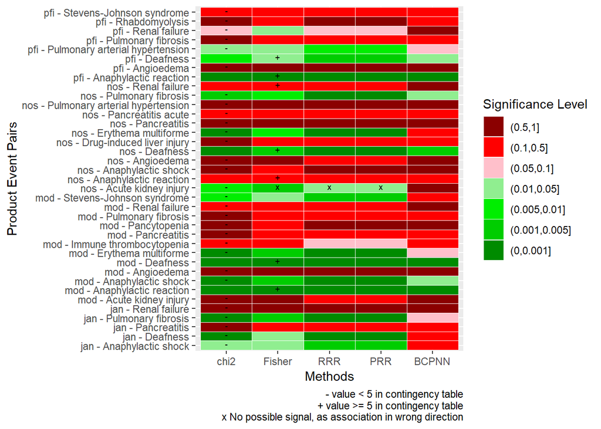

```r
melt_overview_l %>% ggplot(aes(x = variable, y = paste(Product, Event, sep = " - "))) +
        geom_tile(aes(fill = `Significance Level`), colour = "white") +
        scale_fill_manual(breaks = c("(0.5,1]", "(0.1,0.5]", "(0.05,0.1]", "(0.01,0.05]", "(0.005,0.01]", "(0.001,0.005]", "(0,0.001]"),
                        values = c("darkred", "red", "pink", "lightgreen", "green2", "green3", "green4")) +
        xlab("Methods") +
        ylab("Product Event Pairs") +
        geom_text(aes(x = variable, y = paste(Product, Event, sep = " - "), label = Label), size = 2.5, nudge_y = 0.2)+
        labs(caption =  "- value < 5 in contingency table\n+ value >= 5 in contingency table\nx No possible signal, as association in wrong direction")
```

## 4.4 Discussion

### 4.4.1 Comparison beween Results of Different Tests

We can see in the graph above that the first 4 Methods ($\chi^{2}$, Fishers exact test, RRR and PRR) give almost in all cases concurring results (possible signal/no possible signal). The only exception is “pfi - Renal failure”, where only Fishers exact test yields a p value <0.05.

BCPNN yielded more conservative results, meaning that for some product event pairs, where the other methods gave a significant result (at the 0.05 level), it did not confirm this (e.g. for “nos - Erythema multiforme”, “mod - Erythema multiforme”, “jan - Pulmonary Fibrosis”, “jan - Deafness”, “jan - Anaphylactic shock”, “pfi - Pulmonary arterial hypertension”), or gave a result with a lower significance level (e.g. “mod - Anaphylactic shock”, “nos - Pulmonary fibrosis”). This makes sense, wehn considering the following quote describing this method:

“[…] but it shrinks the estimate based on a “prior” assumption of no association between drug and event in the absence of data to the contrary. This weighting damps the observed/expected ratio towards the null value, and this dampening effect is increasingly inconsequential as data accumulate. The objective of this is to reduce false positives with limited data support and an inflated crude observed-to-expected ratio."$^{1}$

This would mean that these cases might have less information to work with => e.g. a smaller number of cases in the contingency tables.

We can check if this hypothesis is correct, by calculating the mean for each field of the contingency table for the product event pairs that where rejected by BCPNN, and comparing them to the means of the product event pairs that where confirmed by BCPNN:

```r
#rejected by bcpnn
bcpnn_rej <- cont[c(9, 23, 35, 34, 33, 32),]
#rejected by bcpnn
bcpnn_conf <- cont[c(15, 17, 14, 2, 5, 26, 25),]
#calculate means
bcpnn_rej_m <- bcpnn_rej %>% select(a, b, c, d) %>% apply(., 2, function(x){mean(x) %>% round(., digits = 0)})
bcpnn_conf_m <- bcpnn_conf %>% select(a, b, c, d) %>% apply(., 2, function(x){mean(x) %>% round(., digits = 0)})
#display result
rbind(bcpnn_rej_m, bcpnn_conf_m) %>% kable()
```

|  | a | b | c | d |
| --- | --- | --- | --- | --- |
| bcpnn_rej_m | 2 | 294 | 1157 | 1045049 |
| bcpnn_conf_m | 7 | 963 | 1938 | 1165119 |

The result shows that for the product event pairs, that where “rejected” by BCPNN the number of cases was generally smaller, then for the ones, that where “confirmed” by it.

Another comparison to be made is between the results of $\chi^{2}$ and Fishers exact test. In most cases Fishers exact test yields results at a lower significance level.  
Due to the often low numbers of a, it is probably in general more appropriate to use here.

### 4.4.2 Comparison between Results for Different Products

The group “nos” contains cases that where reported with product as “a covid vaccine” or a similar expression, therefore it contains a mixture of cases the three products.

The following events where found to be possible signals for “nos” by BCPNN:

- Pulmonary fibrosis
- Deafness

Deafness was also found for Pfizer and Moderna. Therefore it makes sense that this association could also be visible in the nos group (Also because Moderna and Pfizer are the Vaccines that where most used in the US).

Pulmonary Fibrosis was not found for any of the products by BCPNN. With the other tests it was only found for Janssen. It is possible that BCPNN rejected it due to a low number of available cases with Janssen. But the association might be significant enough that it is still detectable in the nos group and not rejected by BCPNN due to the higher number of available cases therein.

To confirm this we can look at the numbers of cases in the database and the exact p values for these two records:

```r
cbind(overview[c(5, 35),1:3], cont[c(5, 35), 4:6], overview[c(5, 35),4:8]) %>% kable()
```

|  | Product | Event | Received Cases | b | c | d | chi2 | Fisher | RRR | PRR | BCPNN |
| --- | --- | --- | --- | --- | --- | --- | --- | --- | --- | --- | --- |
| 7 | nos | Pulmonary fibrosis | 4 | 374 | 2359 | 1174870 | 0.0016244 | 0.0074894 | 0.0009745 | 0.0009659 | 0.0233869 |
| 76 | jan | Pulmonary fibrosis | 2 | 316 | 208 | 922315 | 0.0000001 | 0.0024774 | 0.0000035 | 0.0000033 | 0.0886338 |

We see that we have overall lower case numbers for Janssen. The p values for the test other then BCPNN are all lower for Janssen then for nos, suggesting that the association is diluted in the nos group.

The following events where found to be possible signals for “nos” by the other tests:

- Pulmonary fibrosis (as already discussed)
- Erythema Multiforme
- Deafness

Erythema Multiforme was only found for Moderna (for the other two products there where not even any cases) If we look at the casenumbers and the test results for these two product event pairs, we see again that the association is diluted in the nos group. The number of cases are very similar between the two groups, except for c (cases with the drug but another ADR), which leads to less significant results in the tests.

```r
cbind(overview[c(9, 23),1:3], cont[c(9, 23), 4:6], overview[c(9, 23),4:8]) %>% kable()
```

|  | Product | Event | Received Cases | b | c | d | chi2 | Fisher | RRR | PRR | BCPNN |
| --- | --- | --- | --- | --- | --- | --- | --- | --- | --- | --- | --- |
| 16 | nos | Erythema multiforme | 2 | 67 | 2361 | 1175181 | 0.0002494 | 0.0086371 | 0.0002159 | 0.0002163 | 0.1060700 |
| 39 | mod | Erythema multiforme | 2 | 65 | 960 | 1154247 | 0.0000000 | 0.0014774 | 0.0000009 | 0.0000009 | 0.0859609 |

Deafness was found in all three other products (with the highest significance in Moderna, then Janssen and Pfizer).

```r
cbind(overview[c(2, 14, 25, 33),1:3], cont[c(2, 14, 25, 33), 4:6], overview[c(2, 14, 25, 33),4:8]) %>% kable()
```

|  | Product | Event | Received Cases | b | c | d | chi2 | Fisher | RRR | PRR | BCPNN |
| --- | --- | --- | --- | --- | --- | --- | --- | --- | --- | --- | --- |
| 2 | nos | Deafness | 7 | 933 | 2356 | 1174305 | 0.0007679 | 0.0032590 | 0.0005715 | 0.0005601 | 0.0046057 |
| 25 | mod | Deafness | 6 | 911 | 956 | 1153393 | 0.0000001 | 0.0001403 | 0.0000007 | 0.0000006 | 0.0004682 |
| 48 | pfi | Deafness | 7 | 933 | 2995 | 1173666 | 0.0079209 | 0.0113611 | 0.0047117 | 0.0046545 | 0.0153425 |
| 71 | jan | Deafness | 2 | 698 | 208 | 921933 | 0.0007769 | 0.0113604 | 0.0003576 | 0.0003414 | 0.1098785 |

As we see in the table above nos shows here result with higher significance then Pfizer, which is probably due to the strong association of Moderna, which is again also found in a diluted manner in nos. Here again we see that BCPNN assessed the result for nos as more significant then for Janssen, which goes contrary to RRR and PRR. This is probably again due to the lower number of available cases for Janssen.

A mentioned previously for nos - Acute kidney injury we got p-values that would suggest significance of the results, but the found association was in the wrong direction, meaning there where less cases reported then would have been expected (as compared to the number of cases received in the whole database.)

```r
cbind(overview[1,1:3], cont[1, 4:6], overview[1,4:8]) %>% kable()
```

| Product | Event | Received Cases | b | c | d | chi2 | Fisher | RRR | PRR | BCPNN |
| --- | --- | --- | --- | --- | --- | --- | --- | --- | --- | --- |
| nos | Acute kidney injury | 2 | 5879 | 2361 | 1169369 | 0.0065877 | 0.001117 | 0.0119977 | 0.0118011 | 0.995159 |

### 4.4.3 Conclusion

As measures of disproportionality assume underreporting to be similar for the database in general and the product in question, it can have an influence if this is not the case.  
In the case of covid vaccines I would assume that underreporting was lower, as the vaccines (and also related policy measures) received a lot of media attention and where discussed thoroughly. Therefore I think, that more events where reported than usual.  
This would mean that the associations found here would be overstated.

In practice the results above would then lead to further investigations of the associated cases, before a decision would be made to regard it as signal or not.

From the results here I consider especially the Anaphylactic Reaction/Shock as a possible signal, as this is a known side effect of vaccinations in general and is also biologically plausible. For example if the disinfection of the skin before the vaccination is not done properly, it is possible that pathogens or other substances could be introduced into the body, which can lead to anaphylactic reactions.

### 4.4.4 Possible improvements

When applying the different tests it was not considered, that the we only considered the two possibilities:  
- There is a positive association between drug administration and occurrence of an event  
- There is no association between drug administration and occurrence of an event

and not:  
- There is a negative association between drug administration and occurrence of an event

Therefore the test should have been applied as one tailed. This could have been specified for example for Fishers exact test in the function as follows: fisher.test(alternative = “greater”). As I understand this would have improved the power of the respective tests.

# 5 Appendix

## 5.1 Citations

$^{1}$ Chapter 20 “Quantitative Signal Detection and Analysis in Pharmacovigilance” of “MANN’S PHARMACOVIGILANCE THIRD EDITION” edited by E. ANDREWS and N. MOORE, 2014 by John Wiley & Sons, Ltd.

$^{2}$ “Primer on Disproportionality Analysis” Version: 2018-10-16 by Ruwen Böhm (Uni Kiel)

$^{3}$ RDocumentation for mdsstat::bcpnn function

## 5.2 Drop the created tables from the FEARS Database

```sql
drop if exists covac_nos_d;
drop if exists covac_nos_g;

drop if exists covac_pfi_d;
drop if exists covac_pfi_g;

drop if exists covac_mod_d;
drop if exists covac_mod_g;

drop if exists covac_jan_d;
drop if exists covac_jan_g;

drop if exists covac_ast_d;
drop if exists covac_ast_g;

drop if exists ast_label;
drop if exists mod_label;
drop if exists pfi_label;
drop if exists jan_label;
drop if exists nos_label;

drop if exists selected_events;
drop if exists cont_res;
```

## 5.3 Create Tables: Drugs

- Moderna

```sql
create temporary table covac_mod_all
select * from drugs
where medicinalproduct in
    (select * from covid_vac_mod);
```

```sql
create table covac_mod_d
select * from covac_mod_all
where drugcharacterization = 1;
```

```sql
drop table if exists covac_mod_all;
```

- Pfizer/BioNTech

```sql
create temporary table covac_pfi_all
select * from drugs
where medicinalproduct in
    (select * from covid_vac_pfi);
```

```sql
create table covac_pfi_d
select * from covac_pfi_all
where drugcharacterization = 1;
```

```sql
drop table if exists covac_pfi_all;
```

- Jansen

```sql
create temporary table covac_jan_all
select * from drugs
where medicinalproduct in
    (select * from covid_vac_jan);
```

```sql
create table covac_jan_d
select * from covac_jan_all
where drugcharacterization = 1;
```

```sql
drop table if exists covac_jan_all;
```

- AstraZeneca

```sql
create temporary table covac_ast_all
select * from drugs
where medicinalproduct in
    (select * from covid_vac_ast);
```

```sql
create table covac_ast_d
select * from covac_ast_all
where drugcharacterization = 1;
```

```sql
drop table if exists covac_ast_all;
```

## 5.4 Create Tables: General

Extract the data for these cases from the general table analogous to above.

- NOS

```sql
create table covac_nos_g
select * from general
where safetyreportid in
    (select distinct safetyreportid from covac_nos_d);
```

- Moderna

```sql
create table covac_mod_g
select * from general
where safetyreportid in
    (select distinct safetyreportid from covac_mod_d);
```

- Pfizer/BioNTech

```sql
create table covac_pfi_g
select * from general
where safetyreportid in
    (select distinct safetyreportid from covac_pfi_d);
```

- Janssen

```sql
create table covac_jan_g
select * from general
where safetyreportid in
    (select distinct safetyreportid from covac_jan_d);
```

- AstraZeneca

```sql
create table covac_ast_g
select * from general
where safetyreportid in
    (select distinct safetyreportid from covac_ast_d);
```

## 5.5 Get Selected Events

#jan

```sql
drop table if exists jan_label;
create table jan_label (
    jan_label_id int not null,
    jan_label_def varchar(100),
    primary key (jan_label_id));

LOAD DATA INFILE 'C:/ProgramData/MySQL/MySQL Server 8.0/Uploads/jan_label.csv'
INTO TABLE jan_label
FIELDS TERMINATED BY ';'
ENCLOSED BY ''
LINES TERMINATED BY '\r\n'
IGNORE 1 ROWS;
```

count of cases in scope per events

```sql
insert selected_events(PT)
with reactioncounts as (
    select reactionmeddrapt, count(reactionmeddrapt) as `count`
    from reactions
    where safetyreportid in
        (select distinct safetyreportid from covac_jan_d)
    group by reactionmeddrapt
    order by count(reactionmeddrapt) desc)
select reactionmeddrapt from reactioncounts
where reactionmeddrapt in (select dme_name from dme)
and reactionmeddrapt not in (select jan_label_def from jan_label)
and `count` >= 4;
```

no events added

#mod

```sql
drop table if exists mod_label;
create table mod_label (
    mod_label_id int not null,
    mod_label_def varchar(100),
    primary key (mod_label_id));

LOAD DATA INFILE 'C:/ProgramData/MySQL/MySQL Server 8.0/Uploads/mod_label.csv'
INTO TABLE mod_label
FIELDS TERMINATED BY ';'
ENCLOSED BY ''
LINES TERMINATED BY '\r\n'
IGNORE 1 ROWS;
```

count of cases in scope per events

```sql
insert selected_events(PT)
with reactioncounts as (
    select reactionmeddrapt, count(reactionmeddrapt) as `count`
    from reactions
    where safetyreportid in
        (select distinct safetyreportid from covac_mod_d)
    group by reactionmeddrapt
    order by count(reactionmeddrapt) desc)
select reactionmeddrapt from reactioncounts
where reactionmeddrapt in (select dme_name from dme)
and reactionmeddrapt not in (select mod_label_def from mod_label)
and `count` >= 4;
```

9 events added

#pfi

```sql
drop table if exists pfi_label;
create table pfi_label (
    pfi_label_id int not null,
    pfi_label_def varchar(100),
    primary key (pfi_label_id));

LOAD DATA INFILE 'C:/ProgramData/MySQL/MySQL Server 8.0/Uploads/pfi_label.csv'
INTO TABLE pfi_label
FIELDS TERMINATED BY ';'
ENCLOSED BY ''
LINES TERMINATED BY '\r\n'
IGNORE 1 ROWS;
```

count of cases in scope per events

```sql
insert selected_events(PT)
with reactioncounts as (
    select reactionmeddrapt, count(reactionmeddrapt) as `count`
    from reactions
    where safetyreportid in
        (select distinct safetyreportid from covac_pfi_d)
    group by reactionmeddrapt
    order by count(reactionmeddrapt) desc)
select reactionmeddrapt from reactioncounts
where reactionmeddrapt in (select dme_name from dme)
and reactionmeddrapt not in (select pfi_label_def from pfi_label)
and `count` >= 4;
```

## 5.6 Test calculation of measures of disproportionality

Before I got all the data for the contingency tables for the selected events I first got some single values for some product event pairs and did some calculations:

start with Myocarditis for astra zeneca it was in the media that the pfizer vaccine can cause myocarditis (especially in young men)

what territory and which timeperiod? territory: one with lots of cases time period: since its on the market in respective territory?

how much data is there per country?

```sql
select occurcountry, count(distinct safetyreportid) from `general`
where safetyreportid in
    (select distinct safetyreportid
    from covac_ast_d)
group by occurcountry
order by count(occurcountry) desc;
```

many cases from GB almost 800

```sql
select drugstartdate, count(distinct g.safetyreportid) from covac_ast_d d
join `general` g on d.safetyreportid = g.safetyreportid
where occurcountry = "GB"
group by drugstartdate
order by drugstartdate desc;
```

there are some cases from feb 2020. Check if they are from studies there are many missing values

```sql
select d.drugstartdate, g.receivedate, l.reporttype_def from covac_ast_d d
join `general` g on d.safetyreportid = g.safetyreportid
join lu_reporttype l on g.reporttype = l.reporttype
where g.occurcountry = "GB"
and d.drugstartdate like "2020%";
```

all are spontaneous reports and where received in FEB 2021 (after the reported drugstartdates) => the reported dates are wrong

we take as period the time after 31.12.2020 => include cases that wher received on 31.12.2020 or after. receivedate = date of first receipt by FDA receiptdate = date of latest receipt by FDA (latest version)

as not every case has information about drugstartdate it would not be possible to use this to define the period therefore I will use the receivedate to define the period

when was the first astra zeneca case from GB received by FDA?

```sql
select g.receivedate, count(distinct g.safetyreportid) from covac_ast_d d
join `general` g on d.safetyreportid = g.safetyreportid
where occurcountry = "GB"
group by receivedate
order by receivedate desc;
```

one case was received on 20201211

```sql
select g.* from covac_ast_d d
join `general` g on d.safetyreportid = g.safetyreportid
where g.occurcountry = "GB"
and g.receivedate = "20201211";
```

this must be a mistake, as the report is marked as spontaneous (which would be impossible) and the case event date is stated as 20210226

we will take the administration of the first vaccine as startdate for the period => receivedate >= “20210104”

get data for contingency table: => 2x2 contingency table + Drug - Drug + ADR a b - ADR c d

- - Drug + ADR

```sql
select count(safetyreportid) from reactions
where safetyreportid in
    (select distinct g.safetyreportid from covac_ast_d d
    join `general` g on d.safetyreportid = g.safetyreportid
    where g.occurcountry = "GB"
    and g.receivedate >= "20210104")
and reactionmeddrapt = "Myocarditis";
```

2 cases

- - Drug - ADR

```sql
with dist_cases as
    (select distinct safetyreportid from covac_ast_d)
select count(safetyreportid)
from dist_cases;
```

1167 - 3 = 1164

- - Drug + ADR

```sql
with dist_cases as
    (select distinct g.safetyreportid
    from reactions r
    join `general` g on r.safetyreportid = g.safetyreportid
    where g.occurcountry = "GB"
    and g.receivedate >= "20210104"
    and r.reactionmeddrapt = "Myocarditis")
select count(safetyreportid)
from dist_cases;
```

74 - 3 = 71

- - Drug - ADR => get total number of cases in DB and then calculate from there

```sql
with dist_cases as
    (select distinct safetyreportid
    from `general`
    where occurcountry = "GB"
    and receivedate >= "20210104")
select count(safetyreportid)
from dist_cases;
```

38’492 - Drug - ADR cases: 38’492 -2 -1’164 -71 = 37’255

=> 2x2 contingency table + Drug - Drug + ADR 2 71 - ADR 1164 37’255

PRR (proportional reporting ratio) = (a/(a+b))/(c/(c+d)) = (2/73)/(1164/38’419) = 0.90

reporting odd ratio = ad/bc = 0.90

repeat for myocarditis and pericarditis

- - Drug + ADR

```sql
select count(safetyreportid) from reactions
where safetyreportid in
    (select distinct g.safetyreportid from covac_ast_d d
    join `general` g on d.safetyreportid = g.safetyreportid
    where g.occurcountry = "GB"
    and g.receivedate >= "20210104")
and reactionmeddrapt in ("Myocarditis", "Pericarditis");
```

7 cases

- - Drug - ADR 1167 - 7 = 1160
- - Drug + ADR

```sql
with dist_cases as
    (select distinct g.safetyreportid
    from reactions r
    join `general` g on r.safetyreportid = g.safetyreportid
    where g.occurcountry = "GB"
    and g.receivedate >= "20210104"
    and r.reactionmeddrapt in ("Myocarditis", "Pericarditis"))
select count(safetyreportid)
from dist_cases;
```

122 - 7 = 115

- - Drug - ADR 3’210’899 38’492 -7 -1’160 -115 = 37’210

=> 2x2 contingency table + Drug - Drug + ADR 7 115 - ADR 1160 37’210

PRR (proportional reporting ratio) = (a/(a+b))/(c/(c+d)) = (7/122)/(1164/38’419) = 1.90

reporting odd ratio = ad/bc = 1.95

=> granularity of the adverse reaction has quite an impact here.

I will continue in R to write all the statements “en masse”, as there are many statements needed I will also need to write the results of the querries into a results table in MySQL so I can export them later

try again for pfizer in US how much data is there per country?

```sql
select occurcountry, count(distinct safetyreportid) from `general`
where safetyreportid in
    (select distinct safetyreportid
    from covac_pfi_d)
group by occurcountry
order by count(occurcountry) desc;
```

US has most reports

- - Drug + ADR

```sql
select count(safetyreportid) from reactions
where safetyreportid in
    (select distinct g.safetyreportid from covac_pfi_d d
    join `general` g on d.safetyreportid = g.safetyreportid
    where g.occurcountry = "US"
    and g.receivedate >= "20201213")
and reactionmeddrapt = "Myocarditis";
```

4 cases

- - Drug - ADR

```sql
with dist_cases as
    (select distinct safetyreportid from covac_pfi_d)
select count(safetyreportid)
from dist_cases;
```

3002 - 4 = 2998

- - Drug + ADR

```sql
with dist_cases as
    (select distinct g.safetyreportid
    from reactions r
    join `general` g on r.safetyreportid = g.safetyreportid
    where g.occurcountry = "US"
    and g.receivedate >= "20201213"
    and r.reactionmeddrapt = "Myocarditis")
select count(safetyreportid)
from dist_cases;
```

185 - 4 = 181

- - Drug - ADR => get total number of cases in DB and then calculate from there

```sql
with dist_cases as
    (select distinct safetyreportid
    from `general`
    where occurcountry = "US"
    and receivedate >= "20201213")
select count(safetyreportid)
from dist_cases;
```

1’177’910 1’177’910 -4 -2998 -181 = 1’174’727

```
+ Drug      - Drug
```

- ADR 4 181
- ADR 2998 1’177’910

ROR = 8.68

and now together with pericarditis

- - Drug + ADR

```sql
select count(safetyreportid) from reactions
where safetyreportid in
    (select distinct g.safetyreportid from covac_pfi_d d
    join `general` g on d.safetyreportid = g.safetyreportid
    where g.occurcountry = "US"
    and g.receivedate >= "20201213")
and reactionmeddrapt in ("Myocarditis", "Pericarditis");
```

9

- Drug - ADR 3002 - 9 = 2993
- - Drug + ADR

```sql
with dist_cases as
    (select distinct g.safetyreportid
    from reactions r
    join `general` g on r.safetyreportid = g.safetyreportid
    where g.occurcountry = "US"
    and g.receivedate >= "20201213"
    and r.reactionmeddrapt in ("Myocarditis", "Pericarditis"))
select count(safetyreportid)
from dist_cases;
```

345 - 9 = 336

- - Drug - ADR 1’177’910 1’177’910 -9 -2993 -336 = 1’174’572

=> 2x2 contingency table + Drug - Drug + ADR 9 336 - ADR 2993 1’174’572

ROR = 10.5